# Reproducible Research: Peer Assessment 1

## Are there differences in activity patterns between weekdays and weekends?

1. Create a new factor variable in the dataset with two levels – “weekday” and “weekend” indicating whether a given date is a weekday or weekend day.

```r
## Change the console language to English ##
system("defaults write org.R-project.R force.LANG en_US.UTF-8")
filled_activity$day <- weekdays(as.Date(filled_activity$date))
week_character <- function(day){
        if(day %in% c("Saturday", "Sunday"))
                return("weekend")
        else
                return("weeday")
}
filled_activity$weektype <- sapply(filled_activity$day, week_character)
```

2.Make a panel plot containing a time series plot (i.e. type = “l”) of the 5-minute interval (x-axis) and the average number of steps taken, averaged across all weekday days or weekend days (y-axis). See the README file in the GitHub repository to see an example of what this plot should look like using simulated data.

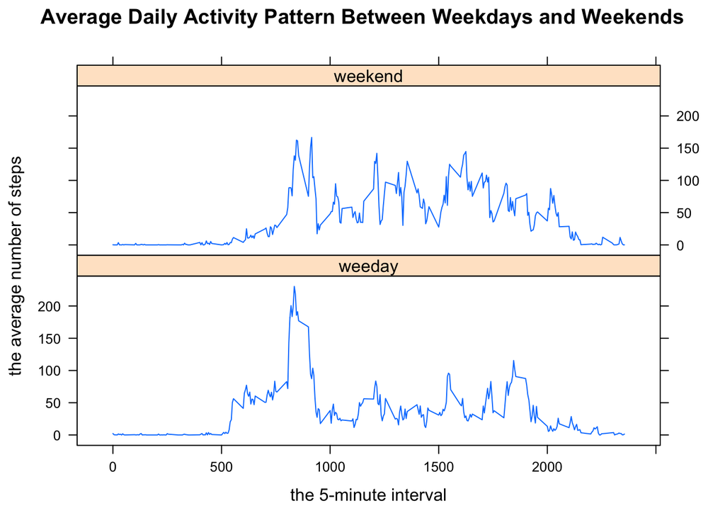

```r
library(lattice)
filled_StepsInterval <- aggregate(steps ~ interval + weektype, filled_activity, mean, na.rm = TRUE)
xyplot(steps ~ interval | weektype, filled_StepsInterval, type = "l", xlab = "the 5-minute interval", ylab = "the average number of steps", main = "Average Daily Activity Pattern Between Weekdays and Weekends", layout = c(1,2))
```